# Intro_to_R_Project

```r
R.version.string
```

```
## [1] "R version 3.4.2 (2017-09-28)"
```

```r
Sys.Date()
```

```
## [1] "2017-11-22"
```

The data set I will be using is a set of Single Nucleotide Polymorphisms (SNPs) for 70 samples found through Whole Genome Sequencing (WGS). The SNPs in this analysis pertain to the pharmacogene SLCO1B1, which is important in the metabolism of statins, and other drugs. The SNPs were filtered from VCF files using the bioinformatics Astrolabe developed (https://www.nature.com/articles/npjgenmed20157). Whole genome sequences were obtained from the Genome Center data warehouse at Children’s Mercy Hospital. The samples used were purchased from Coriell biorepository (https://www.coriell.org/).

```r
#Reading data into R
variants <- read.table('rformat.txt',sep=',',header = TRUE)
head(variants)
```

```
##   Samples  Hap1  Hap2                    SNP Gender
## 1 HG00276 NV_01 NV_02 12~21331625~21331625~T      1
## 2 HG00276 NV_01 NV_02 12~21329738~21329738~G      1
## 3 HG00276 NV_01 NV_02 12~21331549~21331549~C      1
## 4 HG00276 NV_01 NV_02 12~21331599~21331599~C      1
## 5 HG00276 NV_01 NV_02 12~21284010~21284010~C      1
## 6 HG00276 NV_01 NV_02 12~21331987~21331987~T      1
```

```r
tail(variants)
```

```
##     Samples  Hap1  Hap2                    SNP Gender
## 497 NA21781 NV_02 NV_05 12~21331549~21331549~C      0
## 498 NA21781 NV_02 NV_05 12~21284010~21284010~C      0
## 499 NA21781 NV_02 NV_05 12~21392562~21392562~G      0
## 500 NA21781 NV_02 NV_05 12~21392562~21392562~G      0
## 501 NA21781 NV_02 NV_05 12~21392586~21392586~G      0
## 502 NA21781 NV_02 NV_05 12~21392586~21392586~G      0
```

Genders were obtained from the Coriell Biorepository website (Males = 0, Females = 1)

```r
#Factoring sample genders
variants$gender.factor <- factor(variants$Gender,levels = 0:1, labels = c('Males','Females'))
```

Barplot showing the frequency of each SNP

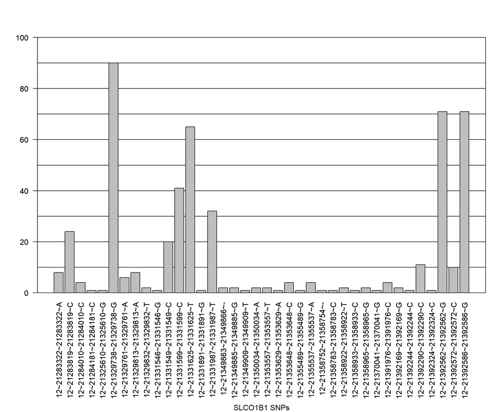

```r
#Setting margins for the plot
par(mar=c(13,4.1,4.1,2))
#Plotting SNPs
barplot(table(variants$SNP),las =2,ylim=c(0,100),)
#Creating lines at 10 point intervals
abline(h=1:10 *10)
#Redrawing barplot to on the lines
barplot(table(variants$SNP),add=TRUE,las=2)
#Labeling plot
mtext(text = 'SLCO1B1 SNPs', side = 1, line = 12)
box()
```

Haplotype phasing is an important and difficult task in genetics. It involves segregating each variant found in an individual to a particular chromosome. A number of bioinformatics tools perform this task through predictive modeling of large datasets to determine the most likely haplotypes. I will be doing a very simplified version of this by checking if there is a strong positive correlation between any two variants, and plotting the correlation values using the “corrplot” r library.

```r
#Loading the corrplot library
library(corrplot)
#Create a png of the plot (to increase size in html file)
png(height=1500,width=1500,file='correlation.png')
#Calculating the correlation between SNPs
M <- cor(table(variants$Sample,variants$SNP))
#Creating plot
corrplot(M,type="upper",method = "circle",tl.pos='td',tl.cex = 1.5)
#Closing image
dev.off()
```

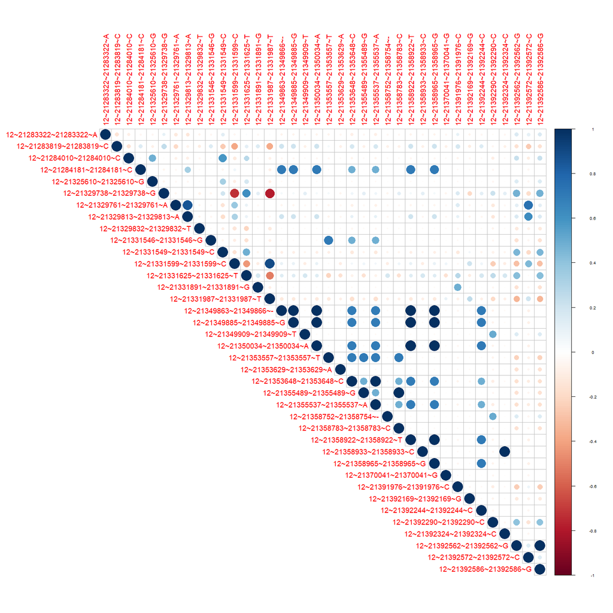

```r
#Loading the knitr library to include the png in the html file
library(knitr)
knitr::include_graphics('C:/Users/ryanl/OneDrive/Documents/Intro-to-R/correlation.png')
```

Calculating how often haplotypes occur together. Each haplotype will infer a functional level to the coded protein, so a person with two non-functional haplotype would have no protein function.

```r
#Creating a new data frame with only a single column for each sample with haplotype information
haps <-unique(variants[,1:3])
#Calculating the proportion where each haplotype occured together
prop.table(table(haps$Hap1,haps$Hap2))
```

```
##
##                  1         21         27         30      NV_01      NV_02
##   1     0.09859155 0.02816901 0.01408451 0.00000000 0.05633803 0.01408451
##   14    0.00000000 0.00000000 0.00000000 0.00000000 0.00000000 0.00000000
##   15    0.00000000 0.02816901 0.00000000 0.00000000 0.00000000 0.00000000
##   19    0.00000000 0.01408451 0.00000000 0.00000000 0.00000000 0.00000000
##   20    0.00000000 0.00000000 0.00000000 0.01408451 0.00000000 0.00000000
##   21    0.00000000 0.00000000 0.00000000 0.00000000 0.01408451 0.00000000
##   24    0.00000000 0.00000000 0.00000000 0.00000000 0.00000000 0.00000000
##   5     0.00000000 0.02816901 0.00000000 0.00000000 0.00000000 0.00000000
##   NV_01 0.00000000 0.00000000 0.00000000 0.00000000 0.09859155 0.05633803
##   NV_02 0.00000000 0.00000000 0.00000000 0.00000000 0.00000000 0.01408451
##   NV_05 0.00000000 0.00000000 0.00000000 0.00000000 0.00000000 0.00000000
##   NV_08 0.00000000 0.00000000 0.00000000 0.00000000 0.00000000 0.00000000
##
##              NV_03      NV_05      NV_06      NV_08      NV_10      NV_11
##   1     0.00000000 0.01408451 0.02816901 0.19718310 0.00000000 0.00000000
##   14    0.00000000 0.00000000 0.00000000 0.01408451 0.00000000 0.00000000
##   15    0.00000000 0.00000000 0.00000000 0.00000000 0.00000000 0.00000000
##   19    0.00000000 0.00000000 0.00000000 0.00000000 0.00000000 0.00000000
##   20    0.00000000 0.00000000 0.01408451 0.01408451 0.00000000 0.00000000
##   21    0.00000000 0.00000000 0.00000000 0.00000000 0.00000000 0.00000000
##   24    0.00000000 0.00000000 0.02816901 0.00000000 0.00000000 0.00000000
##   5     0.00000000 0.00000000 0.00000000 0.01408451 0.00000000 0.00000000
##   NV_01 0.01408451 0.00000000 0.04225352 0.00000000 0.00000000 0.00000000
##   NV_02 0.01408451 0.02816901 0.00000000 0.02816901 0.00000000 0.00000000
##   NV_05 0.00000000 0.00000000 0.00000000 0.01408451 0.00000000 0.00000000
##   NV_08 0.00000000 0.00000000 0.00000000 0.02816901 0.01408451 0.01408451
```

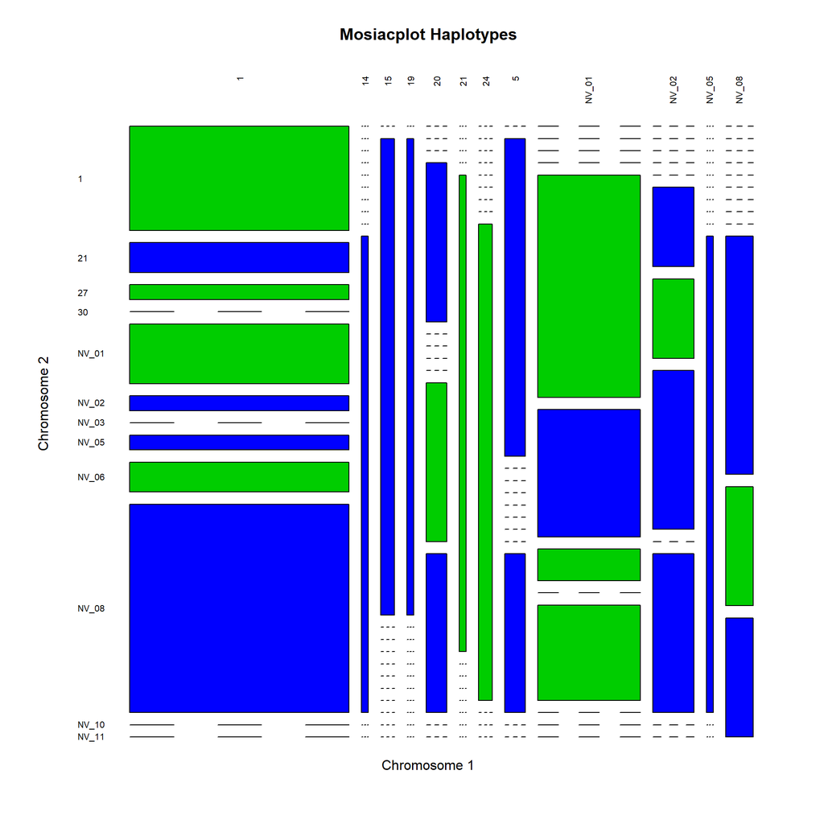

```r
#Mosaic plot of data
mosaicplot(haps$Hap1~haps$Hap2,las=2,color=99:100, xlab='Chromosome 1',ylab='Chromosome 2',main="Mosiacplot Haplotypes")
```